# Mulheres negras: Interseccionalidade de gênero e raça

Pablo Castro

2026-06-19

# 1 Introdução

As desigualdades vivenciadas pelas mulheres negras no Brasil não resultam da soma simples de dois fatores de discriminação — ser mulher e ser negra —, mas de sua combinação indissociável, que produz uma forma singular e agravada de vulnerabilidade social. Este texto examina as condições de vida das mulheres negras a partir de uma perspectiva interseccional, articulando gênero, raça e classe social como eixos de análise simultâneos.

O conceito de interseccionalidade, cunhado pela intelectual Kimberlé Crenshaw em 1989, parte da premissa de que as dinâmicas de poder e a subordinação social são interdependentes, produzindo desvantagens que não podem ser compreendidas isoladamente por um único eixo de opressão. No Brasil, feministas negras como Lélia Gonzalez e Luiza Bairros já articulavam essa perspectiva antes mesmo da sistematização do conceito, ao denunciar que as mulheres negras estão sempre em situação de desvantagem quando comparadas às mulheres brancas e aos homens negros e brancos.

Em conformidade com o Plano de Trabalho Geral, a análise utiliza microdados do Censo Demográfico 2022 (IBGE) para construir indicadores socioeconômicos com recorte simultâneo de gênero e raça, abrangendo: (i) acesso ao ensino superior e trajetórias educacionais; (ii) inserção no mercado de trabalho formal e informal; (iii) concentração no trabalho doméstico remunerado; (iv) chefia de domicílio e arranjos familiares; e (v) maternidade e fecundidade. Os resultados evidenciam que a dupla discriminação de gênero e raça se traduz em desvantagens cumulativas e persistentes, com implicações diretas para a formulação de políticas públicas.

# 2 Educação e Qualificação Profissional

## 2.1 Acesso ao Ensino Superior

A Figura 2.1 apresenta a distribuição do nível superior completo por gênero e raça. As mulheres brancas lideram com 37,2% de diplomação, seguidas pelos homens brancos (26,0%), mulheres negras (22,4%) e homens negros (14,4%).

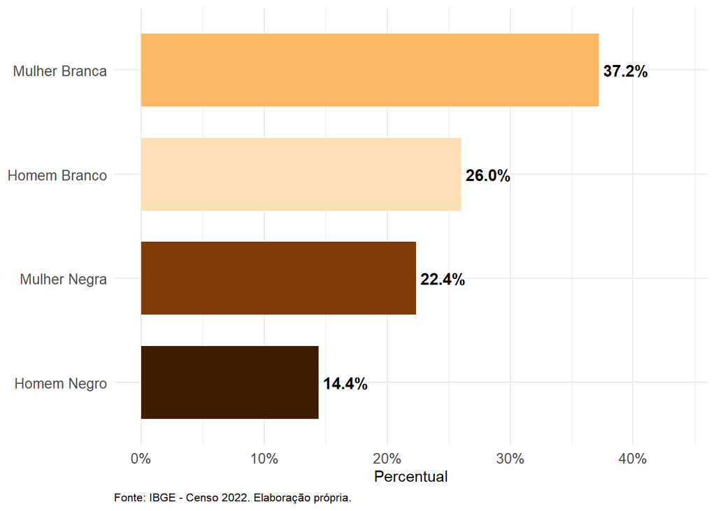

Figure 2.1: Distribuição do nível superior completo por gênero e raça — Brasil, 2022

A diferença entre mulheres brancas e mulheres negras (14,8 pontos percentuais) é maior do que a diferença entre mulheres e homens dentro do grupo branco (11,2 pp), o que evidencia que a desigualdade racial supera, em magnitude, a desigualdade de gênero no acesso à educação superior. Ao mesmo tempo, as mulheres negras superam os homens negros em 8 pp, demonstrando que, mesmo dentro das comunidades negras, as mulheres avançaram mais na escolarização, ainda que partindo de uma base desigual em relação aos grupos brancos.

## 2.2 Áreas de Formação Superior

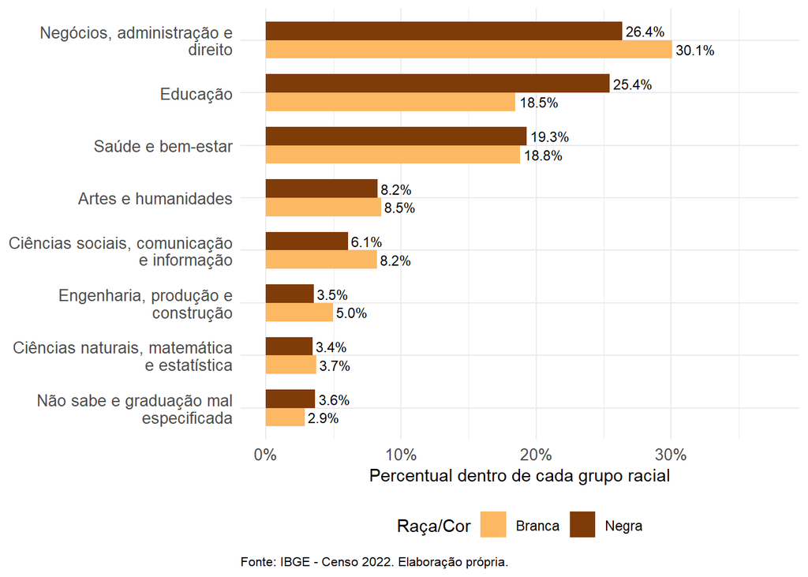

Figure 2.2: Áreas de formação superior por raça entre mulheres // Top 8 áreas por volume total — Brasil, 2022

A maior concentração de mulheres negras em Educação — 25,4% do total de mulheres negras com ensino superior completo, ante 18,5% entre as brancas — e sua menor presença em áreas de maior retorno salarial, como Engenharia, produção e construção (3,5% vs. 5,0%) e Ciências sociais, comunicação e informação (6,1% vs. 8,2%), refletem padrões de segregação educacional com implicações diretas sobre a inserção no mercado de trabalho e a mobilidade social. Esses percentuais expressam a distribuição intragrupo: cada valor indica qual fração das diplomadas daquele grupo racial concluiu o curso naquela área, de modo que os totais somam 100% dentro de cada categoria racial. Essa diferenciação nas trajetórias de formação não resulta apenas de escolhas individuais, mas de constrangimentos estruturais ligados à disponibilidade de cursos acessíveis, à localização geográfica das instituições de ensino e às desigualdades acumuladas ao longo da trajetória escolar.

## 2.3 Defasagem Educacional no Ensino Básico

A Figura 2.3 apresenta o tipo de ensino frequentado por pessoas de 18 anos ou mais por gênero e raça. A proporção de pessoas na modalidade EJA (Educação de Jovens e Adultos) — indicador de defasagem educacional acumulada — é maior entre mulheres negras (8,1% no Fundamental EJA e 8,6% no Médio EJA) do que entre os demais grupos.

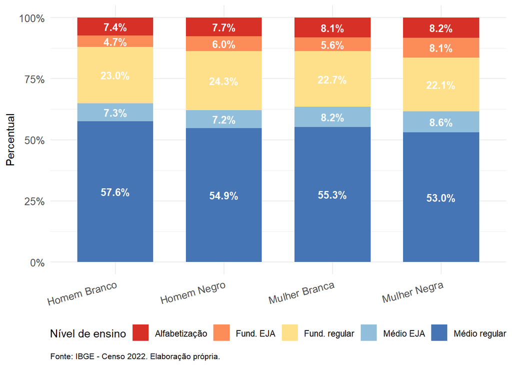

Figure 2.3: Tipo de ensino frequentado por pessoas de 18+ por gênero e raça - Brasil, 2022

A soma das modalidades EJA (Fundamental e Médio) chega a 16.7% entre mulheres negras e 13.2% entre homens negros, contra 12.0% entre homens brancos e 13.8% entre mulheres brancas. Esses dados evidenciam que a defasagem escolar atinge de forma desigual a população negra, com as mulheres negras suportando simultaneamente as consequências do racismo estrutural na educação e as interrupções escolares frequentemente associadas a responsabilidades domésticas e à maternidade precoce.

# 3 Inserção no Mercado de Trabalho

A segmentação do mercado de trabalho por gênero e raça constitui um dos eixos mais visíveis da dupla discriminação vivenciada pelas mulheres negras, com implicações diretas sobre renda, proteção social e autonomia econômica.

## 3.1 Tipo de Inserção Ocupacional

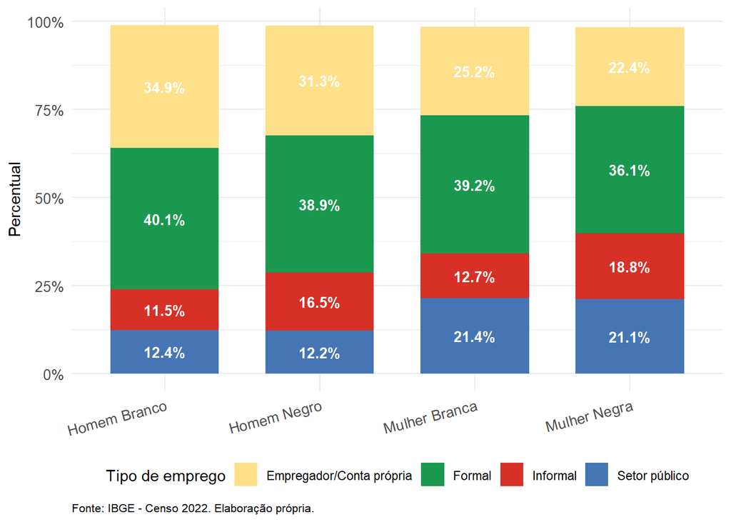

Figure 3.1: Tipo de inserção no mercado de trabalho por gênero e raça - Brasil, 2022

## 3.2 Concentração no Trabalho Doméstico Remunerado

A Figura 3.2 apresenta a concentração no trabalho doméstico remunerado por gênero e raça. As mulheres negras representam 65,2% de todos os trabalhadores domésticos no Brasil, seguidas pelas mulheres brancas (30,2%), homens negros (3,3%) e homens brancos (1,3%).

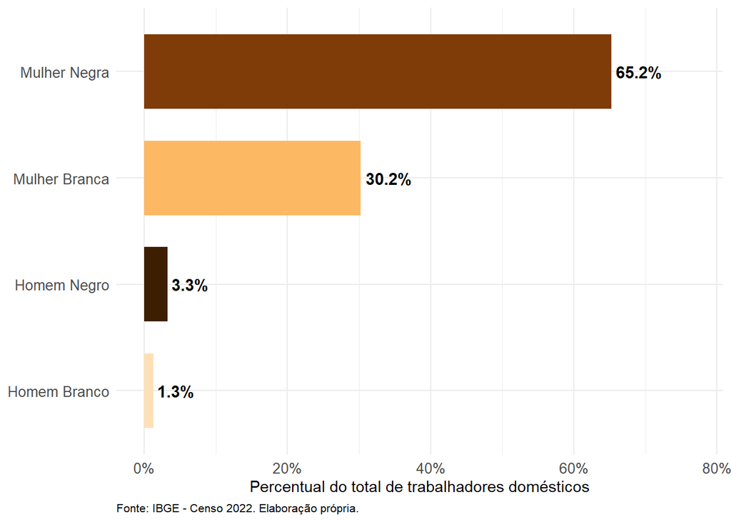

Figure 3.2: Concentração no trabalho doméstico remunerado por gênero e raça - Brasil, 2022

A concentração de dois terços de todos os trabalhadores domésticos remunerados entre mulheres negras é um dado emblemático da herança histórica da escravidão no Brasil, que associou o trabalho de cuidado e limpeza doméstica à população negra feminina como uma forma de perpetuação das hierarquias raciais e de gênero. O trabalho doméstico, ainda que regulamentado pela Emenda Constitucional nº 72/2013 e pela Lei Complementar nº 150/2015, segue marcado por informalidade e por remuneração abaixo da média nacional, configurando uma armadilha estrutural para a mobilidade econômica das mulheres negras.

# 4 Chefia de Domicílio e Arranjos Familiares

A chefia de domicílio por mulheres negras revela um padrão de vulnerabilidade estrutural que combina responsabilidades familiares ampliadas com menor acesso a renda, proteção social e serviços públicos.

## 4.1 Distribuição Regional da Chefia Feminina Negra

A Figura 4.1 apresenta as unidades da federação com maior proporção de mulheres negras como responsáveis pela família. O Amapá lidera com 46,3%, seguido pelo Maranhão (45,4%), Amazonas (43,9%), Bahia (43,6%) e Sergipe (43,1%).

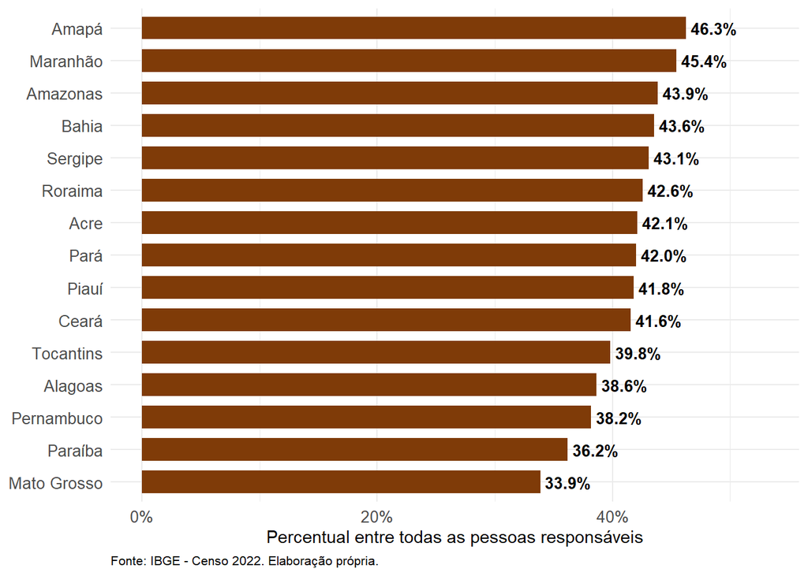

Figure 4.1: UFs com maior proporção de mulheres negras como responsáveis pela família - Brasil, 2022

Os estados com maior concentração de chefia feminina negra são predominantemente das regiões Norte e Nordeste, onde se combinam altas proporções populacionais negras, maior informalidade no mercado de trabalho e menor acesso a políticas de proteção social. Essa distribuição geográfica sugere que a chefia feminina negra está associada a contextos de maior vulnerabilidade econômica e social, em que a ausência do parceiro ou cônjuge não resulta necessariamente de escolha, mas de dinâmicas de migração masculina, encarceramento em massa e violência, fenômenos que afetam desproporcionalmente os homens negros.

## 4.2 Nível de Instrução das Mulheres Responsáveis pela Família

A Figura 4.2 apresenta o nível de instrução das mulheres responsáveis pela família por raça. Entre as chefes de família negras, 38,0% não têm instrução ou possuem apenas o fundamental incompleto, contra 27,5% entre as brancas. No nível superior completo, a diferença se inverte: 24,9% entre brancas e apenas 11,3% entre negras.

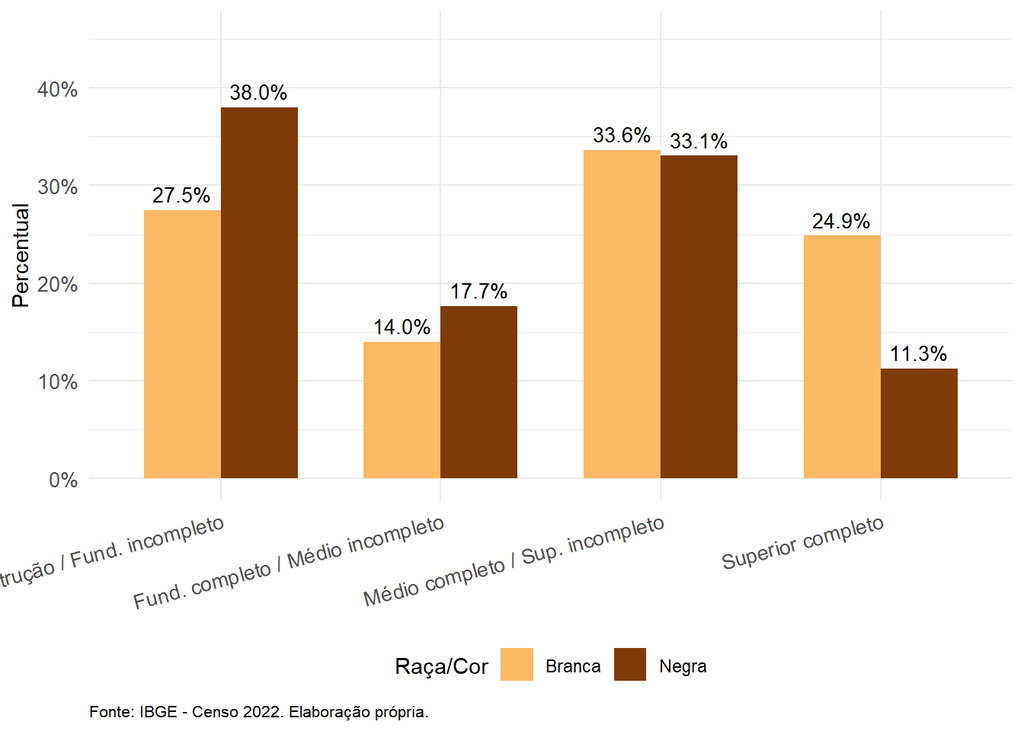

Figure 4.2: Nível de instrução de mulheres responsáveis pela família por raça - Brasil, 2022

A combinação entre baixa escolaridade e responsabilidade pela chefia do domicílio cria um ciclo de vulnerabilidade particularmente severo para as mulheres negras: sem qualificação adequada, elas acessam postos de trabalho precários e de baixa remuneração, o que compromete sua capacidade de prover condições adequadas de vida para seus filhos e dependentes, reproduzindo intergeracionalmente as desigualdades. A escolaridade média mais alta entre as chefes brancas (24,9% com superior completo vs. 11,3% entre negras) representa também maior capacidade de acesso a crédito, moradia adequada e serviços de qualidade.

# 5 Maternidade, Cuidado e Reprodução Social

As responsabilidades reprodutivas e de cuidado configuram uma dimensão central da sobrecarga vivenciada pelas mulheres negras, articulando gênero, raça e classe em trajetórias de vida marcadas por menor autonomia e maiores restrições à participação econômica e educacional.

## 5.1 Maternidade Adolescente por Raça

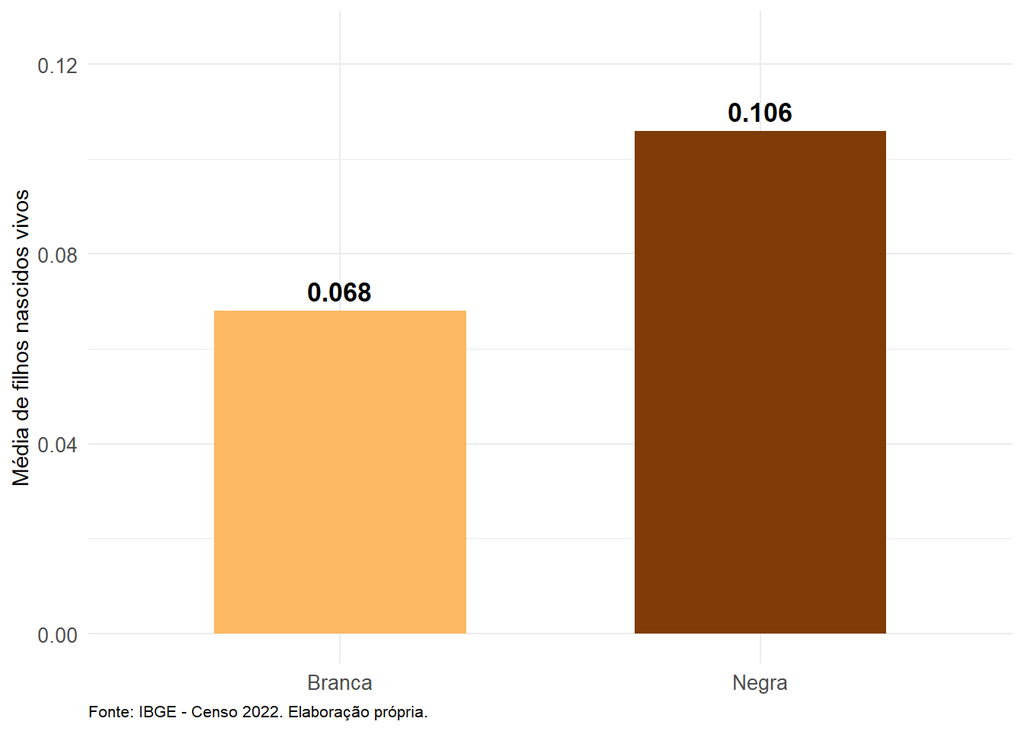

A maternidade adolescente mais frequente entre meninas negras está associada a menor acesso a educação sexual de qualidade, a serviços de saúde reprodutiva e a informações sobre planejamento familiar, refletindo desigualdades no acesso a direitos. A gravidez na adolescência interrompe trajetórias escolares e projetos de vida, contribuindo para a reprodução intergeracional da pobreza e para a sobrerrepresentação de mulheres negras em ocupações de baixa qualificação.

## 5.2 Fecundidade por Raça e Faixa Etária

A Figura 5.2 apresenta a média de filhos nascidos vivos por raça e faixa etária entre mulheres de 12 anos ou mais. A diferença racial na fecundidade se mantém em todas as faixas etárias: mulheres negras apresentam média sistematicamente superior, chegando a 3,58 filhos entre as de 50 anos ou mais, contra 2,82 entre as brancas.

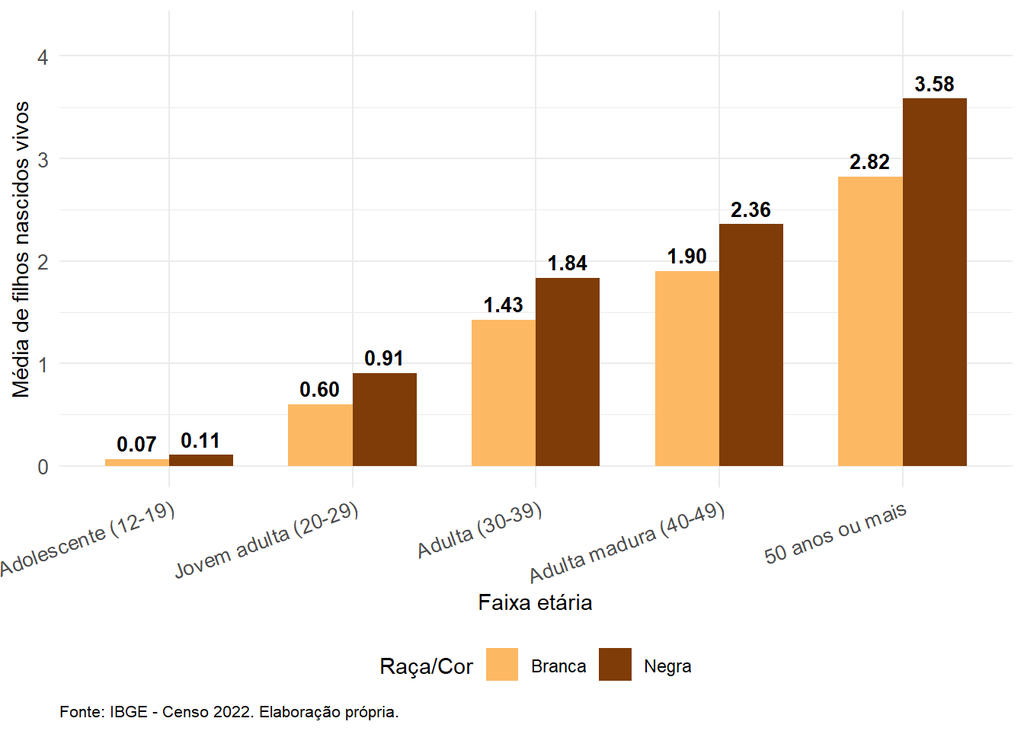

## 5.3 Violência Doméstica e Saúde Reprodutiva: uma Lacuna de Dados a Reconhecer

A interseccionalidade de gênero e raça vivenciada pelas mulheres negras se manifesta de forma particularmente grave também na exposição à violência doméstica e nas condições de saúde reprodutiva — incluindo mortalidade materna, acesso a pré-natal adequado e a métodos contraceptivos. Esses dois eixos não são tratados com indicadores próprios neste texto, e é importante explicitar o motivo: o Censo Demográfico 2022, base de dados utilizada em toda a análise, **não coleta informações sobre violência doméstica nem sobre os desfechos de saúde reprodutiva e materna** (mortalidade materna, acompanhamento pré-natal, complicações obstétricas), uma vez que se trata de um levantamento demográfico amplo, e não de um sistema de vigilância em saúde ou de segurança pública.

A literatura especializada (IPEA, 2013; PINHEIRO et al., 2016), baseada em registros administrativos de saúde e segurança pública, já documenta que mulheres negras apresentam taxas de mortalidade materna e de homicídio por violência doméstica substancialmente superiores às de mulheres brancas no Brasil, o que não foi possível verificar diretamente no âmbito deste produto em razão da indisponibilidade desses dados na base censitária utilizada.

# 6 Considerações sobre Interseccionalidade e Políticas Públicas

No campo educacional, a distância de 14,8 pontos percentuais no acesso ao ensino superior entre mulheres brancas (37,2%) e negras (22,4%) expressa décadas de exclusão histórica, parcialmente mitigada pelas políticas de cotas raciais implementadas a partir dos anos 2000. A maior concentração de mulheres negras em cursos de menor retorno salarial, como Educação, e sua defasagem acumulada no ensino básico — evidenciada pela maior presença na modalidade EJA — reforçam que o acesso à universidade, por si só, é insuficiente para equalizar trajetórias marcadas por desigualdades estruturais.

No mercado de trabalho, as mulheres negras enfrentam simultaneamente a segregação ocupacional horizontal (concentração em trabalho doméstico) e vertical (menor acesso a cargos de liderança), com taxas de informalidade que comprometem o acesso a direitos trabalhistas e previdenciários. A representação de 65,2% das trabalhadoras domésticas entre mulheres negras é um indicador emblemático de como o racismo e o sexismo se articulam para confinar esse grupo em ocupações historicamente desvalorizadas e precárias.

A chefia de domicílio por mulheres negras — particularmente expressiva no Norte e Nordeste, onde chega a 46,3% no Amapá — combina responsabilidades ampliadas de cuidado com baixa escolaridade (38,0% sem instrução ou com fundamental incompleto) e menor acesso a renda e proteção social, criando ciclos de vulnerabilidade que se reproduzem intergeracionalmente. A maternidade adolescente mais frequente entre negras (0,106 vs. 0,068 entre brancas) e a fecundidade total mais alta em todas as faixas etárias completam o quadro de sobrecarga reprodutiva que restringe a autonomia e as oportunidades de vida dessas mulheres. Como discutido na Seção 5, esse quadro é ainda mais grave quando se considera que os indicadores de violência doméstica e de saúde reprodutiva — não capturados pelo Censo Demográfico — tendem a reproduzir, segundo a literatura especializada, o mesmo padrão de desvantagem cumulativa das mulheres negras observado nos indicadores socioeconômicos aqui analisados.

O Sistema Nacional de Promoção da Igualdade Racial (SINAPIR), instituído pela Lei nº 12.288/2010 (Estatuto da Igualdade Racial), constitui o principal instrumento de articulação federativa das políticas de promoção da igualdade racial no Brasil, mas seus planos de ação têm historicamente tratado as desigualdades de raça e de gênero como eixos paralelos, sem a devida incorporação do enfoque interseccional que os dados aqui apresentados demonstram ser indispensável. Os resultados deste texto — que evidenciam desvantagens cumulativas e não meramente aditivas para as mulheres negras em educação, trabalho, chefia familiar e reprodução — reforçam a necessidade de que o SINAPIR articule suas ações com a Política Nacional de Políticas para as Mulheres, de modo a produzir diagnósticos e políticas que reconheçam explicitamente a especificidade da posição das mulheres negras, e não apenas a soma de políticas de gênero e de raça concebidas isoladamente.

Para superar essas desigualdades estruturais, são necessárias políticas públicas que operem simultaneamente sobre os múltiplos eixos de discriminação: garantia de qualidade na educação básica em territórios de maioria negra; ampliação e manutenção de cotas raciais e de gênero no ensino superior e no mercado de trabalho; fortalecimento da regulamentação e fiscalização do trabalho doméstico; expansão de serviços de saúde reprodutiva e educação sexual; e investimento em equipamentos públicos de cuidado — creches, escolas de tempo integral e centros de assistência social — que permitam às mulheres negras reduzir a sobrecarga do trabalho reprodutivo e ampliar sua participação econômica e educacional. Apenas com uma agenda interseccional e antirracista, que reconheça a especificidade das experiências das mulheres negras, será possível avançar rumo a uma sociedade genuinamente igualitária.

# Referências

BRASIL. Emenda Constitucional nº 72, de 2 de abril de 2013. Altera a redação do parágrafo único do art. 7º da Constituição Federal para estabelecer a igualdade de direitos trabalhistas entre os trabalhadores domésticos e os demais trabalhadores urbanos e rurais. Brasília: Diário Oficial da União, 2013.

BRASIL. Lei nº 12.288, de 20 de julho de 2010. Institui o Estatuto da Igualdade Racial e o Sistema Nacional de Promoção da Igualdade Racial (SINAPIR). Brasília: Diário Oficial da União, 2010.

BRASIL. Lei Complementar nº 150, de 1º de junho de 2015. Dispõe sobre o contrato de trabalho doméstico. Brasília: Diário Oficial da União, 2015.

CRENSHAW, Kimberlé. Demarginalizing the intersection of race and sex: a black feminist critique of antidiscrimination doctrine, feminist theory and antiracist politics. University of Chicago Legal Forum, v. 1989, n. 1, 1989.

CRENSHAW, Kimberlé. Mapeando as margens: interseccionalidade, políticas de identidade e violência contra mulheres de cor. Cadernos Pagu, n. 43, p. 133–167, 2012.

GONZALEZ, Lélia. A categoria político-cultural de amefricanidade. Tempo Brasileiro, n. 92/93, p. 69–82, 1988.

IBGE. Censo Demográfico 2022. Rio de Janeiro: IBGE, 2023.

IPEA. Mulheres negras: retrato das desigualdades de gênero e raça. Brasília: IPEA/SPM/ONU Mulheres, 2013.

OLIVEIRA, Eleonora Menicucci de. A mulher, a sexualidade e o trabalho. São Paulo: Hucitec/CUT, 1999.

PINHEIRO, Luana et al. Mulheres e trabalho: breve análise do período 2004–2014. Brasília: IPEA, 2016. (Nota Técnica n. 24).

WERNECK, Jurema. De Ialodês e feministas: reflexões sobre a ação política das mulheres negras na América Latina e no Caribe. Núcleo de Pesquisa, n. 7, 2010.